# Development and Evaluation of Hybrid Multi-Strategy Algorithmic Trading Systems

## Integrating Technical Screening, Options Volatility, and Social Sentiment

**Course:** MSDS-696 - Data Science Practicum II - Regis University  
**Author:** John Holub  
**Last Updated:** December 7, 2025

## Table of Contents

1. Project Overview
2. Data Sources and Acquisition
3. Sentiment Analysis from Reddit
4. Clustering Market Regimes
5. Technical Screener for Alpha Generation
6. Strategy Backtesting
7. Future Roadmap and Research Directions
8. References

### 1. Project Overview:

This project aims at generating consistent, risk-controlled returns in all conditions of financial markets by identifying short-term high-frequency alpha and leveraging quantitative methods for disciplined portfolio management. The system integrates:

- **Sentiment Indicator:** Scraping and classifying text from defined financial subreddits (e.g., r/WallStreetBets, r/stocks, etc).
- **ML Clustering of Market Type Regimes:** K-means clustering to help determine what regime (bull, bear, neutral) market is in.
- **Technical Screener:** High-speed filtering of tickers based on technical conditions.
- **Strategy Testing:** Evaluating effectiveness of several hybrid trading systems.
- **Intergration & Automation:** A framework for backtesting and paper trading.
- **Future Research and Work Direction:** Plans for future research, continued development and application.

### 2. Data Sources and Acquisition

- **Reddit Posts** (r/WallStreetBets, r/stocks, etc.): Used for social sentiment signals.
- **CBOE Weekly Options Tickers**: Ticker list of weekly options universe.
- **Daily Historical Data Yahoo Finance** (via yfinance): Equity price and volume data.
- **Intraday and Options Data** (IBKR or Thinkorswim APIs): Increased data granularity, if required. As well as automation intregration.

```python
# Library imports
# Keep currrent with new library additions as needed. This helps with documentation and future notebooks drafts.
# Basic imports for data work
import pandas as pd
import numpy as np

# Visualization
import matplotlib.pyplot as plt
import seaborn as sns
from wordcloud import wordcloud
import dash

# NLP / ML
import nltk
from nltk.sentiment.vader import SentimentIntensityAnalyzer
from nltk.corpus import stopwords
from collections import Counter
from sklearn.ensemble import RandomForestClassifier
from sklearn.cluster import KMeans

# Data / Trading
import requests
# import praw # Note: Disabbled for now, Reddit made API private end of Nov 2025.
import yfinance as yf
import pandas_ta as ta #technical analysis library
import vectorbt as vbt
from ib_insync import IB

# Misc
import datetime as dt
import time
```

```python
# Only required on first run
nltk.download('vader_lexicon')

nltk.download('stopwords')
stopwords_set = set(stopwords.words('english'))
```

```python
# Ticker list for yahoo historical data acquisition and reddit ticker extraction
# Source CBOE weekly optionable ETFs/equities from CBOE (updated weekly): https://www.cboe.com/available_weeklys/
import pandas as pd
import requests

url = "https://www.cboe.com/available_weeklys/get_csv_download/"
headers = {"User-Agent": "Mozilla/5.0"}
csv_text = requests.get(url, headers=headers).text

print(csv_text[:3000])  # Preview down to ETF section
```

```
List of Available Weekly Options
"Standard","12/12/25","","","","","",""
"Expanded","12/12/25","12/26/25","01/02/26","01/09/26","01/23/26","","","","",""
"End of Week","12/12/25","12/26/25","01/02/26","01/09/26","01/23/26","","","","",""
"Equity/ETF/ETN (MON)","12/08/25","12/15/25","12/22/25","","","","","","",""
"Equity/ETF/ETN (TUE)","12/09/25","12/16/25","","","","","","",""
"Equity/ETF/ETN (WED)","12/10/25","12/17/25","","","","","","",""
"Equity/ETF/ETN (THUR)","12/11/25","12/18/25","","","","","","",""
"XSP (MON)","12/08/25","12/15/25","12/22/25","12/29/25","01/05/26","",""
"XSP (TUE)","12/09/25","12/16/25","12/23/25","12/30/25","01/06/26","",""
"XSP (WED)","12/10/25","12/17/25","12/24/25","01/07/26","01/14/26","",""
"XSP (THUR)","12/11/25","12/18/25","01/08/26","01/15/26","","",""
"XSP (EOW)","12/12/25","12/26/25","01/02/26","01/09/26","01/23/26","",""
"SPXW (MON)","12/08/25","12/15/25","12/22/25","12/29/25","01/05/26","01/12/26",""
"SPXW (TUE)","12/09/25","12/16/25","12/23/25","12/30/25","01/06/26","01/13/26",""
"SPXW (WED)","12/10/25","12/17/25","12/24/25","12/31/25","01/07/26","01/14/26",""
"SPXW (THU)","12/11/25","12/18/25","01/08/26","01/15/26","01/22/26","",""
"SPXW (EOW)","12/12/25","12/26/25","01/02/26","01/09/26","01/23/26","01/30/26",""
"VIX","12/10/25","12/24/25","12/31/25","01/07/26","","",""
"NANOS (MON)","12/08/25","12/15/25","","","","",""
"NANOS (WED)","12/10/25","","","","","",""
"NANOS (EOW)","12/12/25","","","","","",""

Available Weeklys - Exchange Traded Products (ETFs and ETNs)
"AGQ","PROSHARES TR II ULTRA SILVER NEW"
"AMDL","GRANITESHARES ETF TR GRANITE 2X LONG"
"ARKG","ARK Genomic Revolution ETF"
"ARKK","ARK Innovation ETF"
"ASHR","DBX ETF TR XTRACK HRVST CSI"
"BITO","PROSHARES TR BITCOIN ETF"
"BITX","2x Bitcoin Strategy ETF"
"BOIL","PROSHARES TR II ULTRA BLOOMBERG"
"CONL","GRANITESHARES ETF TR 2X LONG COIN DAI"
"DIA","SPDR DOW JONES INDL AVERAGE ET UT SER 1"
"DPST","DIREXION SHS ETF TR DAILY REGIONAL"
"EEM","ISHARES TR MSCI EMG MKT ETF"
"EFA","ISHARES TR MSCI EAFE ETF"
"EMB","ISHARES TR JPMORGAN USD EMG"
"ETH","GRAYSCALE ETHEREUM MINI TR ETF SHS NEW"
"ETHA","ISHARES ETHEREUM TR SHS"
```

[output cut: 8 more lines]

```
"GBTC","GRAYSCALE BITCOIN TRUST ETF SHS REP COM UT"
"GDX","VANECK ETF TRUST GOLD MINERS ETF"
"GDXJ","VANECK ETF TRUST JUNIOR GOLD MINE"
"GLD","SPDR GOLD TR GOLD SHS"
"HYG","ISHARES TR IBOXX HI YD ETF"
"IAU","ISHARES GOLD TR ISHARES NEW"
"IBIT","ISHARES BITCOIN TRUST ETF SHS BEN INT"
"ICLN","ISHARES TR GL CLEAN ENE ETF"
"IEF","ISHARES TR 7-10 YR TRSY BD"
"ITB","iShares U.S. Home Construction ETF"
"IVV","ISHARES TR CORE S&P500 ETF"
"IWM","ISHARES TR RUSSELL 2000 ETF"
"IYR","ISHARES TR U.S. REAL ES ETF"
"JETS","ETF SER SOLUTIONS US GLB JETS"
"
```

```python
lines = csv_text.splitlines()
```

```python
# Haven't changed in many months but check periodically on CBOE
etf_start = lines.index("Available Weeklys - Exchange Traded Products (ETFs and ETNs)")
equity_start = lines.index("Available Weeklys - Equity")
```

```python
# This will extract Ticker and Name
def get_rows(start_index):
    rows = []
    for line in lines[start_index+1:]:
        line = line.strip()
        if not line:  # stop at the first empty line
            break
        if line.startswith('"'):  # include only rows with data
            rows.append(line)
    return rows

etf_rows = get_rows(etf_start)
equity_rows = get_rows(equity_start)
```

```python
print("ETF rows:", len(etf_rows))
print(etf_rows[:5])

print("\nEquity rows:", len(equity_rows))
print(equity_rows[:5])
```

```
ETF rows: 103
['"AGQ","PROSHARES TR II ULTRA SILVER NEW"', '"AMDL","GRANITESHARES ETF TR GRANITE 2X LONG"', '"ARKG","ARK Genomic Revolution ETF"', '"ARKK","ARK Innovation ETF"', '"ASHR","DBX ETF TR XTRACK HRVST CSI"']

Equity rows: 560
['"AA","ALCOA CORP COM"', '"AAL","AMERICAN AIRLS GROUP INC COM"', '"AAOI","APPLIED OPTOELECTRONICS INC COM"', '"AAP","ADVANCE AUTO PARTS INC COM"', '"AAPL","APPLE INC COM"']
```

```python
# Make one combined CSV list of current weeklies [ticker, name, type]
combined = []

# Add ETFs
for row in etf_rows:
    row = row.replace('"', '')
    parts = row.split(",", 1)
    ticker = parts[0]
    name = parts[1]
    combined.append([ticker, name, "ETF"])

# Add Equities
for row in equity_rows:
    row = row.replace('"', '')
    parts = row.split(",", 1)
    ticker = parts[0]
    name = parts[1]
    combined.append([ticker, name, "Equity"])

# Write CSV
csv_path = "weekly_options_tickers.csv"
with open(csv_path, "w") as f:
    f.write("Ticker,Name,Type\n")
    for row in combined:
        ticker = row[0]
        name = row[1]
        type_label = row[2]
        f.write(ticker + "," + name + "," + type_label + "\n")

# Preview CSV first and last 5 lines
with open(csv_path, "r") as f:
    lines = [line.strip() for line in f]

print("First 5:")
for line in lines[:5]:
    print(line)

print("\n...\n")

print("Last 5:")
for line in lines[-5:]:
    print(line)
```

```
First 5:
Ticker,Name,Type
AGQ,PROSHARES TR II ULTRA SILVER NEW,ETF
AMDL,GRANITESHARES ETF TR GRANITE 2X LONG,ETF
ARKG,ARK Genomic Revolution ETF,ETF
ARKK,ARK Innovation ETF,ETF

...

Last 5:
XYZ,BLOCK INC CL A,Equity
ZETA,ZETA GLOBAL HOLDINGS CORP CL A,Equity
ZIM,ZIM INTEGRATED SHIPPING SERV SHS,Equity
ZM,ZOOM COMMUNICATIONS INC CL A,Equity
ZS,ZSCALER INC COM,Equity
```

```python
# Download historical OHLCV data from yfinance

# Import CBOE weekly tickers
import pandas as pd

# NOTE: If ParserError check CSV for scraping error adding additional column and manually fix.
weekly = pd.read_csv("weekly_options_tickers.csv")

# Tickers as uppercase (safer for yfinance)
tickers = weekly["Ticker"].astype(str).str.upper().tolist()

print("Number of tickers:", len(tickers))
tickers[:10]  # preview
```

```
Number of tickers: 663
```

```
['AGQ', 'AMDL', 'ARKG', 'ARKK', 'ASHR', 'BITO', 'BITX', 'BOIL', 'CONL', 'DIA']
```

```python
# Download daily data

import yfinance as yf

# Define date range
start_date = "2015-01-01"
end_date = "2025-12-31"

# Download OHLCV data
data = yf.download(
    tickers,
    start=start_date,
    end=end_date,
    group_by="ticker",
    auto_adjust=False
)

data.head()
```

```
[*********************100%***********************]  663 of 663 completed
```

| Ticker Price Date | BTDR Open | BTDR High | BTDR Low | BTDR Close | BTDR Adj Close | BTDR Volume | FIG Open | FIG High | FIG Low | FIG Close | ... | PNC Low | PNC Close | PNC Adj Close | PNC Volume | BUD Open | BUD High | BUD Low | BUD Close | BUD Adj Close | BUD Volume |
| --- | --- | --- | --- | --- | --- | --- | --- | --- | --- | --- | --- | --- | --- | --- | --- | --- | --- | --- | --- | --- | --- |
| 2015-01-02 | NaN | NaN | NaN | NaN | NaN | NaN | NaN | NaN | NaN | NaN | ... | 89.879997 | 90.820000 | 64.329857 | 2083400 | 112.300003 | 112.480003 | 110.980003 | 111.739998 | 88.360847 | 908400 |
| 2015-01-05 | NaN | NaN | NaN | NaN | NaN | NaN | NaN | NaN | NaN | NaN | ... | 88.019997 | 88.040001 | 62.360722 | 3411700 | 109.040001 | 109.709999 | 107.769997 | 108.089996 | 85.474548 | 2010600 |
| 2015-01-06 | NaN | NaN | NaN | NaN | NaN | NaN | NaN | NaN | NaN | NaN | ... | 85.379997 | 85.760002 | 60.745754 | 4422100 | 107.279999 | 108.540001 | 106.570000 | 107.849998 | 85.284737 | 1717700 |
| 2015-01-07 | NaN | NaN | NaN | NaN | NaN | NaN | NaN | NaN | NaN | NaN | ... | 86.089996 | 86.750000 | 61.446999 | 2249200 | 108.440002 | 109.949997 | 108.139999 | 109.419998 | 86.526253 | 1837000 |
| 2015-01-08 | NaN | NaN | NaN | NaN | NaN | NaN | NaN | NaN | NaN | NaN | ... | 87.449997 | 88.419998 | 62.629894 | 2116700 | 111.589996 | 113.769997 | 111.379997 | 112.879997 | 89.262344 | 1257200 |

5 rows × 3978 columns

```python
# Wow! That was surprisingly fast, under 1 min
# Seeing a lot of NaN, probably date related but to check

valid_prices = [t for t in tickers if t in data]
invalid_prices = [t for t in tickers if t not in data]

print("Tickers with price data:", len(valid_prices))
print("Tickers missing data:", len(invalid_prices))
```

```
Tickers with price data: 663
Tickers missing data: 0
```

```python
# Convert yfinance wide format to long format for CSV
import pandas as pd

df_long = (
    data
    .stack(level=0) # Move tickers into their own column
    .reset_index() # Move Date and Ticker out of index
)

# Rename columns for clarity
df_long = df_long.rename(columns={
    "level_1": "Ticker"
})

df_long.head()
```

| Price | Date | Ticker | Open | High | Low | Close | Adj Close | Volume |
| --- | --- | --- | --- | --- | --- | --- | --- | --- |
| 0 | 2015-01-02 | AA | 38.135609 | 38.399940 | 37.655010 | 38.159641 | 35.572781 | 4340408.0 |
| 1 | 2015-01-02 | AAL | 54.279999 | 54.599998 | 53.070000 | 53.910000 | 51.079922 | 10748600.0 |
| 2 | 2015-01-02 | AAOI | 11.280000 | 11.280000 | 10.720000 | 10.790000 | 10.790000 | 184600.0 |
| 3 | 2015-01-02 | AAP | 160.850006 | 162.500000 | 157.470001 | 158.559998 | 139.455185 | 509800.0 |
| 4 | 2015-01-02 | AAPL | 27.847500 | 27.860001 | 26.837500 | 27.332500 | 24.237553 | 212818400.0 |

```python
# Save to CSV
df_long.to_csv("weeklies_prices_long.csv", index=False)
print("Saved weeklies_prices_long.csv")
```

```
Saved weeklies_prices_long.csv
```

## 3. Sentiment Analysis from Reddit

```python
# Config for Reddit Scrape, define subreddits and post limits
# Similar subs were pulled from https://anvaka.github.io/redsim/
HEADERS = {"User-Agent": "Mozilla/5.0"}

SUBREDDITS = [
    # WallStreetBets & Spin-offs
    'wallstreetbets',
   # 'wallstreetbetsOGs',  # Turned off due to low post volume
    'WallStreetbetsELITE',
    'smallstreetbets',

    # Meme Stocks & High Volatility
    'Superstonk',
    'TheRaceTo10Million',
    'shortsqueeze',
    'pennystocks',
    'RobinhoodPennyStocks',

# Below are turned off for now due to class time constraints/noise, and API closure.
    # Options Trading
    # 'options',
    # 'OptionsMillionaire',
    # 'thetagang',
    # 'optionswheel',
    # 'CoveredCalls',

    # General Investing
    # 'stocks',
    # 'investing',
    # 'ValueInvesting',
    # 'StockMarket',
    # 'EarningsWatcher',

    # Technical Analysis
    # 'technicalanalysis',
    # 'Daytrading',
    # 'RealDayTrading',

    # Crypto
    # add later

    # Futures
    # add later
]

LIMIT_PER_SUB = 1000
```

```python
# Batch scrape and sleep parameters here
def fetch_batch(sub, after=None, limit=1000):
    url = f"https://www.reddit.com/r/{sub}/new.json"
    params = {"limit": limit}
    if after:
        params["after"] = after

    try:
        r = requests.get(url, headers=HEADERS, params=params)
    except Exception as e:
        print(f"Request error on r/{sub}: {e}")
        return None, None

    if r.status_code == 429:
        print("Rate-limited. Sleeping...")
        time.sleep(10) # 10 seconds seems to work same as 30
        return None, after

    if r.status_code != 200:
        print(f"HTTP {r.status_code} from r/{sub}")
        return None, None

    data = r.json().get("data", {})
    return data.get("children", []), data.get("after")
```

```python
# Loop through each defined subreddit and pull posts until limit per sub.
# Usually takes about 1 min per sub.
all_posts = []

for sub in SUBREDDITS:
    print(f"\n--- Scraping r/{sub} ---")
    posts = []
    after = None

    while len(posts) < LIMIT_PER_SUB:
        children, after = fetch_batch(sub, after)

        if not children:
            break

        for item in children:
            d = item.get("data", {})
            posts.append({
                "subreddit": sub,
                "title": d.get("title"),
                "selftext": d.get("selftext"),
                "score": d.get("score"),
                "created_utc": dt.datetime.fromtimestamp(d.get("created_utc"))
                    if d.get("created_utc") else None,
                "num_comments": d.get("num_comments")
            })

        time.sleep(2)  # slight rate-limit buffer

    print(f"Collected {len(posts)} posts")
    all_posts.extend(posts)

len(all_posts)
```

```
--- Scraping r/wallstreetbets ---
Collected 1056 posts

--- Scraping r/WallStreetbetsELITE ---
Collected 1090 posts

--- Scraping r/smallstreetbets ---
Collected 1094 posts

--- Scraping r/Superstonk ---
Collected 1095 posts

--- Scraping r/TheRaceTo10Million ---
Collected 1098 posts

--- Scraping r/shortsqueeze ---
Collected 1003 posts

--- Scraping r/pennystocks ---
Collected 1073 posts

--- Scraping r/RobinhoodPennyStocks ---
Collected 1069 posts
```

```
8578
```

```python
# All posts to df
df = pd.DataFrame(all_posts)
```

```python
df['created_utc'] = pd.to_datetime(df['created_utc'], errors='coerce')
df = df.dropna(subset=['created_utc'])  # remove any None timestamps
```

```python
# Extract data for heatmap
df['date'] = df['created_utc'].dt.date
```

```python
# Filter to 2025
df_2025 = df[
    (df['created_utc'] >= "2025-01-01") &
    (df['created_utc'] <  "2026-01-01")
]
```

```python
# Build pivot table for heatmap
heatmap_data = df_2025.pivot_table(
    index='subreddit',
    columns='date',
    values='title',        # for count only
    aggfunc='count',
    fill_value=0
)
```

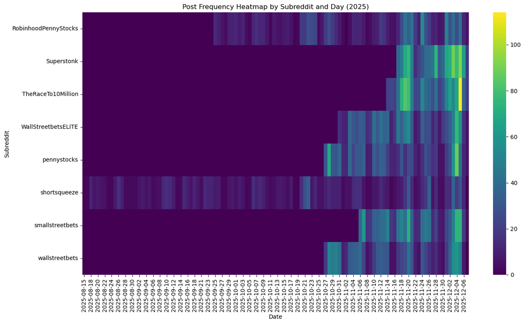

```python
# Plot heatmap of posts by subreddit per day
import pandas as pd
import seaborn as sns
import matplotlib.pyplot as plt

plt.figure(figsize=(14, 8))
sns.heatmap(heatmap_data, cmap="viridis")
plt.title("Post Frequency Heatmap by Subreddit and Day (2025)")
plt.xlabel("Date")
plt.ylabel("Subreddit")
plt.tight_layout()
plt.show()
```

#### Obervations:

- wallstreetbetsOG very low post volume, removed. Considering Removing shortsqueeze as well.
- The more active subs the ~1000 post json limit only goes back aabout a month or two.
- There are activity spikes visible on big earnings report days (e.g., NVDA on 11/19).

```python
# Restore df to all posts
df = pd.DataFrame(all_posts)

# Load VADER and score posts
from nltk.sentiment.vader import SentimentIntensityAnalyzer
import nltk
nltk.download('vader_lexicon')

sia = SentimentIntensityAnalyzer()

df['sentiment'] = df['title'].fillna("").apply(
    lambda x: sia.polarity_scores(x)['compound']
)
```

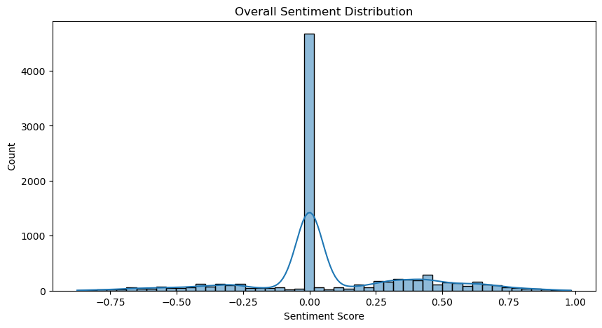

```python
# Plot of Overall Sentiment
import pandas as pd
import seaborn as sns
import matplotlib.pyplot as plt

plt.figure(figsize=(10,5))
sns.histplot(df['sentiment'], bins=50, kde=True)
plt.title("Overall Sentiment Distribution")
plt.xlabel("Sentiment Score")
plt.show()
```

#### Obervations:

- Most posts have a 0.0 sentiment, indicating vast majority of posts are neutral in nature. I think I'll try some further analysis on this to make sure this is accurate, and then filter out sentiment scores of 0.0.
- There is a positive bias, this is not surprising as the markets generally go up and there is always more upside potential than down.
- Most scores (outside of 0.0) are more moderate ~+/-0.25-0.5.

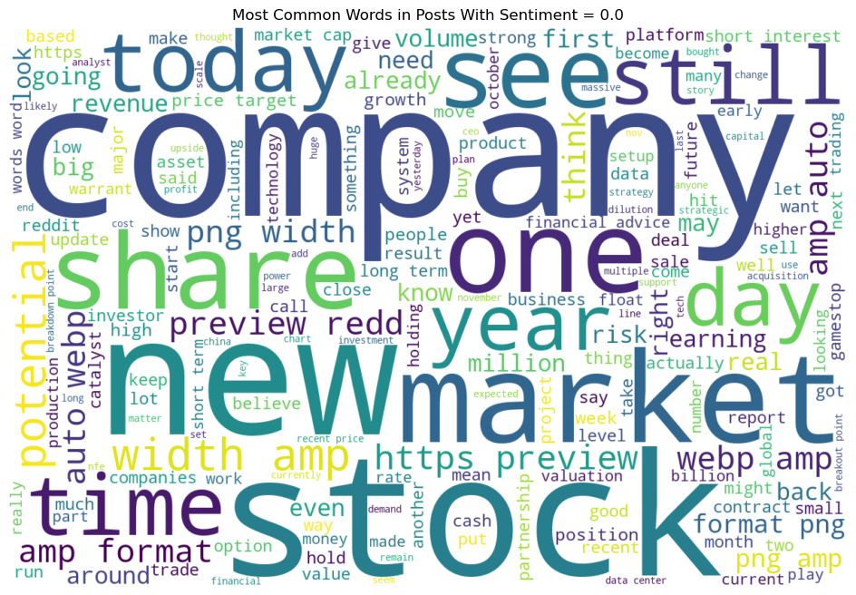

```python
# Quick visual word cloud check of 0.0 sentiment posts
from wordcloud import WordCloud
import matplotlib.pyplot as plt
import nltk, re
from nltk.corpus import stopwords

# Download stop words (also up above)
nltk.download('stopwords')
stopwords_set = set(stopwords.words('english'))

# Filter only zero-sentiment posts
zero_df = df[df['sentiment'] == 0.0]

# Combine title + selftext for text analysis
zero_text_series = (zero_df['title'].fillna('') + ' ' +
                    zero_df['selftext'].fillna('')).str.lower()

# Tokenize
def tokenize(text):
    return re.findall(r"[a-z']+", text)

# Flatten all
all_tokens = []
for t in zero_text_series:
    toks = tokenize(t)
    toks = [tok for tok in toks if tok not in stopwords_set and len(tok) > 2]
    all_tokens.extend(toks)

# Create word cloud
wc = WordCloud(width=1200, height=800, background_color="white").generate(" ".join(all_tokens))

plt.figure(figsize=(12,8))
plt.imshow(wc, interpolation='bilinear')
plt.axis("off")
plt.title("Most Common Words in Posts With Sentiment = 0.0")
plt.show()
```

#### Obervations:

- While this isn't a proper analysis, I think the word cloud gave me the visual confirmation that most of the 0.0 sentiment posts are procedural, mostly news probably, and I can filter them out.
- I'm seeing a lot of evidence of what is probably image only uploads (png, format, width, redd, reddit, preview, webp, etc.)
- Not seeing much for sentiment, individual tickers or indices, so again feel comfortable filtering out 0.0 sentiment.

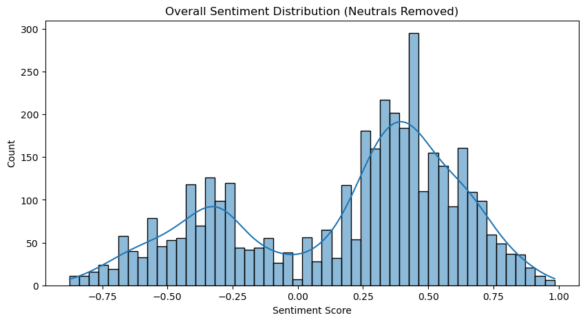

```python
# Remove 0.0 replot
import pandas as pd
import seaborn as sns
import matplotlib.pyplot as plt

df_filtered = df[df['sentiment'] != 0.0]

# Plot of Overall Sentiment <> 0.0
plt.figure(figsize=(10,5))
sns.histplot(df_filtered['sentiment'], bins=50, kde=True)
plt.title("Overall Sentiment Distribution (Neutrals Removed)")
plt.xlabel("Sentiment Score")
plt.show()
```

#### Obervations:

- The sentiment data is much cleaner, and likely more actionable, with 0.0 filtered out.
- There is a positive bias, this is not surprising as the markets generally go up and there is always more upside potential than down.
- Most scores (outside of 0.0) are more moderate ~+/-0.25-0.5, with bimodal peaks around -0.3 and +0.4.

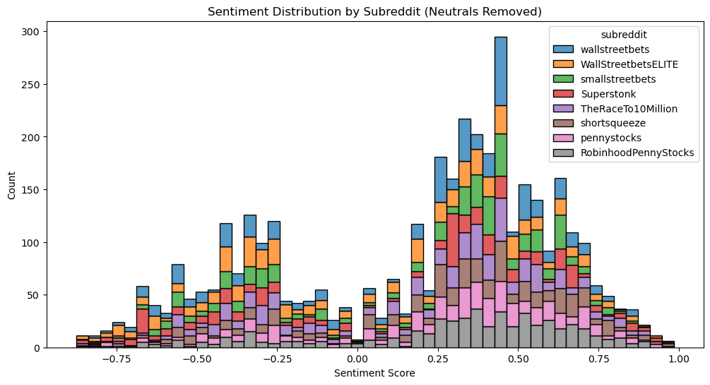

```python
# Stacked Histogram of Subreddit Sentiments
import pandas as pd
import seaborn as sns
import matplotlib.pyplot as plt

plt.figure(figsize=(12, 6))
sns.histplot(
    data=df_filtered,
    x='sentiment',
    hue='subreddit',
    multiple='stack',
    bins=50,
)

plt.title("Sentiment Distribution by Subreddit (Neutrals Removed)")
plt.xlabel("Sentiment Score")
plt.show()
```

#### Obervations:

- Distribution looking fairly normal, outside of:
- Penny stocks have a discernable positive bias, which is not surprising as there isn't much profit in shorting penny stocks.
- A violin plot might show these patterns better.

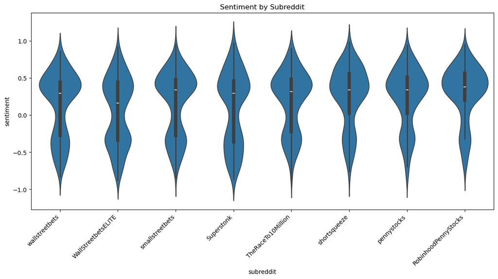

```python
# Violin Plot of Sentiment by Subreddit
import pandas as pd
import seaborn as sns
import matplotlib.pyplot as plt

plt.figure(figsize=(14,6))
sns.violinplot(data=df_filtered, x='subreddit', y='sentiment')
plt.xticks(rotation=45, ha='right')
plt.title("Sentiment by Subreddit")
plt.show()
```

#### Obervations:

```python
# Save neutral filtered sentiment data to CSV for easier future use
csv_path = "reddit_sentiment_filtered.csv"

df_filtered.to_csv(csv_path, index=False)

# Preview CSV first and last 5 lines
with open(csv_path, "r") as f:
    lines = [line.strip() for line in f]

print("First 5:")
for line in lines[:5]:
    print(line)

print("\n...\n")

print("Last 5:")
for line in lines[-5:]:
    print(line)
```

```
First 5:
subreddit,title,selftext,score,created_utc,num_comments,sentiment
wallstreetbets,Is T (ATT) the dumbest company in the universe?,"Today, we talk about ATT

Bought Time Warner for $85B 2018


...

Last 5:
RobinhoodPennyStocks,$CCTG-$IVP DONE..TIME FOR $CCTG GUYS ..LETS MAKE IT GREAT AGAIN LIKE $IVP,,1,2025-11-21 11:14:11,0,0.765
RobinhoodPennyStocks,"$CCTG-AFTER $IVP, ITS TIME TO MAKE $CCTG GREAT AGAIN..LETS PUSH TO $1 💪💪",,0,2025-11-21 11:06:49,0,0.7034
RobinhoodPennyStocks,"$CBDW - Sim Agro has a first right of refusal contract to acquire a data center capable warehouse and power plant. After the acquisition, Sim Agro will become publicly-traded under the ticker “CBDW.”","$CBDW - Sim Agro has a first right of refusal contract to acquire a data cen…
https://finance.yahoo.com/news/1606-corp-signs-term-sheet-130000558.html",1,2025-11-21 10:46:43,0,0.3818
RobinhoodPennyStocks,$CCTG-Called $IVP AND THERE IT GOES..🚀🚀. NEXT BET ON $CCTG..BUY THIS DIP OPPORTUNITY 💪💪💪,,2,2025-11-21 10:41:21,0,0.5473
```

```python
# Prepare for ticker merge from weeklies with reddit sentiment extraction

# Identify potential stopword tickers in weekly CSV
# ParserError: check CSV for extra column scrape errors
import pandas as pd
import nltk
from nltk.corpus import stopwords

nltk.download("stopwords")
stops = set(stopwords.words("english"))

# Load your ticker list
df = pd.read_csv("weekly_options_tickers.csv")

# Standardize tickers to uppercase strings
tickers = df["Ticker"].astype(str).str.upper().tolist()

# Find tickers that are English stopwords (case-insensitive)
stopword_tickers = [t for t in tickers if t.lower() in stops]

print("Tickers that match English stopwords:")
print(stopword_tickers)
```

```
Tickers that match English stopwords:
['BE', 'M', 'MA', 'NOW', 'ON', 'S', 'SO', 'T']
```

```python
# Extract reddit tickers from weekly CSV merge
import pandas as pd

# Load data
df = pd.read_csv("reddit_sentiment_filtered.csv")
weekly = pd.read_csv("weekly_options_tickers.csv")

# Valid tickers from weekly options list
valid = set(weekly["Ticker"].astype(str).str.upper())

# Ignore list: stopwords from above and adding AI preemptively
ignore = {'BE', 'M', 'MA', 'NOW', 'ON', 'S', 'SO', 'T', 'AI'}

# Build full_text (title + selftext)
df["full_text"] = df["title"].fillna("") + " " + df["selftext"].fillna("")

# Ticker extractor with CAPS rule + $ prefix handling
def find_tickers(text):
    if not isinstance(text, str):
        return []

    out = []
    words = text.split()

    for w in words:
        # Remove standard punctuation
        raw = w.strip(".,!?()[]")

        # Allow tickers that start with $
        if raw.startswith("$"):
            clean = raw[1:].upper()
        else:
            clean = raw.upper()

        # Also only allow ALL CAPS tickers
        if raw != raw.upper() and not raw.startswith("$"):
            continue

        # Must be a valid weekly ticker
        if clean not in valid:
            continue

        # Skip defined Ignore list
        if clean in ignore:
            continue

        out.append(clean)

    return out

# Apply extraction
df["tickers_clean"] = df["full_text"].apply(find_tickers)

df.head()
```

|  | subreddit | title | selftext | score | created_utc | num_comments | sentiment | full_text | tickers_clean |
| --- | --- | --- | --- | --- | --- | --- | --- | --- | --- |
| 0 | wallstreetbets | Is T (ATT) the dumbest company in the universe? | Today, we talk about ATT \n\nBought Time Warne... | 1624 | 2025-12-06 16:49:33 | 265 | -0.5106 | Is T (ATT) the dumbest company in the universe... | [WBD, WBD] |
| 1 | wallstreetbets | Calls on AGX (catching a falling knife) | AGX constructs data centers/energy. Earnings... | 59 | 2025-12-06 15:45:59 | 20 | -0.1531 | Calls on AGX (catching a falling knife) AGX co... | [] |
| 2 | wallstreetbets | NFLX acquiring WBD is a good thing. Some Due D... | A few reasons why i think this is good for bot... | 0 | 2025-12-06 07:12:43 | 86 | 0.4404 | NFLX acquiring WBD is a good thing. Some Due D... | [NFLX, WBD, NFLX, IP, NFLX, NFLX, NFLX, NFLX] |
| 3 | wallstreetbets | Good day betting on Nasdaq futures &amp; NY Ce... | On Polyma... oh wait ForecastEx | 350 | 2025-12-06 03:33:55 | 51 | 0.4404 | Good day betting on Nasdaq futures &amp; NY Ce... | [] |
| 4 | wallstreetbets | This week’s plays of selling options. Ended up... | NaN | 57 | 2025-12-05 14:45:57 | 20 | 0.2500 | This week’s plays of selling options. Ended up... | [] |

```python
# Save to CSV
output_file = "reddit_sentiment_with_tickers.csv"
df.to_csv(output_file, index=False)
```

```python
# EDA on sentiment enriched weekly ticker counts
import pandas as pd

df = pd.read_csv("reddit_sentiment_with_tickers.csv")

# Convert string to real python lists
df["tickers_clean"] = df["tickers_clean"].apply(
    lambda x: eval(x) if isinstance(x, str) else x
)
```

```python
# Explode ticket mentions to one per row
df_exp = df.explode("tickers_clean")
df_exp = df_exp[df_exp["tickers_clean"].notna()]
```

```python
ticker_sent = df_exp.groupby("tickers_clean")["sentiment"].agg(
    mentions="count",
    min_sentiment="min",
    avg_sentiment="mean",
    med_sentiment="median",
    max_sentiment="max"
).reset_index()

ticker_sent = ticker_sent.sort_values("mentions", ascending=False)

ticker_sent.head()
```

|  | tickers_clean | mentions | min_sentiment | avg_sentiment | med_sentiment | max_sentiment |
| --- | --- | --- | --- | --- | --- | --- |
| 95 | GME | 251 | -0.8602 | 0.290481 | 0.4129 | 0.9711 |
| 163 | NFE | 148 | -0.7560 | 0.224689 | 0.4215 | 0.8750 |
| 170 | NVDA | 121 | -0.6808 | 0.111038 | 0.3400 | 0.8459 |
| 38 | BYND | 99 | -0.5994 | 0.102635 | 0.2732 | 0.7034 |
| 14 | AMD | 79 | -0.6900 | 0.437377 | 0.6249 | 0.9806 |

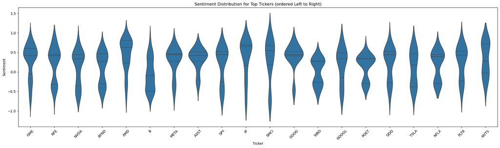

```python
# Violin Plot of Sentiment by Subreddit
import matplotlib.pyplot as plt
import seaborn as sns

# Top tickers mentions
top_tickers = ticker_sent.sort_values("mentions", ascending=False).head(20)["tickers_clean"]

# Filter to only rows for those tickers
plot_data = df_exp[df_exp["tickers_clean"].isin(top_tickers)]

plt.figure(figsize=(20,6))
sns.violinplot(
    data=plot_data,
    x="tickers_clean",
    y="sentiment",
    order=top_tickers,   # ensures left to right order by mentions
    inner="quartile"
)

plt.title("Sentiment Distribution for Top Tickers (ordered Left to Right)")
plt.xlabel("Ticker")
plt.ylabel("Sentiment")
plt.xticks(rotation=45)
plt.tight_layout()
plt.show()
```

#### Obervations:

- Positive bullish sentiment bias visibly present in nearly all tickers.
- One exception being B, Barrick Mining, which I'm speculating could have this negative sentiment due to inherent reddit tech company bias and its recent run up (+100% in 6 months).
- Most tickers have very large ranges showing extreme positive and negative sentiment present.
- Several tickers again have the bimodal opinion peaks, such as BYND, POET, WBD, NFLX.

```python
# Prep ticker sentiment export to join with historical OHLCV data for technical screener
import pandas as pd

# Ensure datetime & daily column
df_exp["created_utc"] = pd.to_datetime(df_exp["created_utc"])
df_exp["date"] = df_exp["created_utc"].dt.date

# Daily sentiment + mentions per ticker
ticker_daily = df_exp.groupby(["tickers_clean", "date"]).agg(
    avg_sentiment=("sentiment", "mean"),
    mentions=("sentiment", "count")
).reset_index()

# Weighted sentiment (mentions × avg sentiment)
ticker_daily["weighted_sentiment"] = (
    ticker_daily["avg_sentiment"] * ticker_daily["mentions"]
)

ticker_daily.head()
```

|  | tickers_clean | date | avg_sentiment | mentions | weighted_sentiment |
| --- | --- | --- | --- | --- | --- |
| 0 | AA | 2025-12-03 | 0.6486 | 2 | 1.2972 |
| 1 | AAOI | 2025-11-11 | 0.2732 | 1 | 0.2732 |
| 2 | AAPL | 2025-11-03 | 0.4215 | 1 | 0.4215 |
| 3 | AAPL | 2025-11-17 | -0.2500 | 1 | -0.2500 |
| 4 | AAPL | 2025-11-18 | 0.4588 | 1 | 0.4588 |

```python
# Add sentiment simple moving averages (SMA) for various daily intervals for later join with technical indicators

# Compute SMAs per ticker
windows = [3, 5, 7, 10, 14, 20]

# Sort based on day for correct calculation
ticker_daily = ticker_daily.sort_values(["tickers_clean", "date"])

for w in windows:
    ticker_daily[f"sma_{w}"] = (
        ticker_daily.groupby("tickers_clean")["avg_sentiment"]
        .rolling(w)
        .mean()
        .reset_index(level=0, drop=True)
    )

ticker_daily.head()
```

|  | tickers_clean | date | avg_sentiment | mentions | weighted_sentiment | sma_3 | sma_5 | sma_7 | sma_10 | sma_14 | sma_20 |
| --- | --- | --- | --- | --- | --- | --- | --- | --- | --- | --- | --- |
| 0 | AA | 2025-12-03 | 0.6486 | 2 | 1.2972 | NaN | NaN | NaN | NaN | NaN | NaN |
| 1 | AAOI | 2025-11-11 | 0.2732 | 1 | 0.2732 | NaN | NaN | NaN | NaN | NaN | NaN |
| 2 | AAPL | 2025-11-03 | 0.4215 | 1 | 0.4215 | NaN | NaN | NaN | NaN | NaN | NaN |
| 3 | AAPL | 2025-11-17 | -0.2500 | 1 | -0.2500 | NaN | NaN | NaN | NaN | NaN | NaN |
| 4 | AAPL | 2025-11-18 | 0.4588 | 1 | 0.4588 | 0.2101 | NaN | NaN | NaN | NaN | NaN |

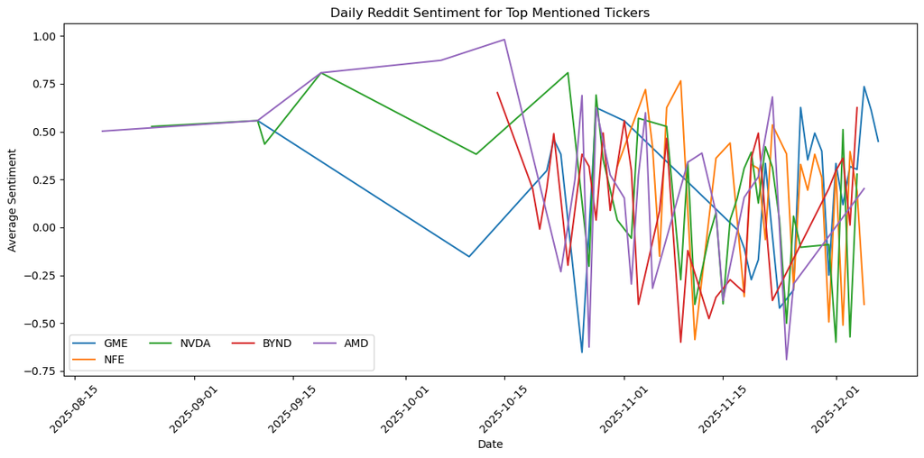

```python
# Line Plot of Sentiment Over Time for Top Tickers
import matplotlib.pyplot as plt
import seaborn as sns

# Top tickers by total mentions
top_tickers = (
    ticker_sent
    .sort_values("mentions", ascending=False)
    .head(5)["tickers_clean"]
)

# Filter to only rows for those tickers
plot_data = ticker_daily[ticker_daily["tickers_clean"].isin(top_tickers)]

plt.figure(figsize=(12,6))

for t in top_tickers:
    sub = plot_data[plot_data["tickers_clean"] == t]
    plt.plot(sub["date"], sub["avg_sentiment"], label=t)

plt.title("Daily Reddit Sentiment for Top Mentioned Tickers")
plt.xlabel("Date")
plt.ylabel("Average Sentiment")
plt.xticks(rotation=45)
plt.legend(loc="lower left", ncol=4)
plt.tight_layout()
plt.show()
```

#### Obervations:

- Extreme variability and noise at the daily level.
- Data gets very thin and unreliable at more than 1 month ago.
- I will use something like a monthly average to try and take some of this noise out.
- While this was an interesting exercise, I don't think this will be a useful indicator, at least not at the daily level.

```python
# Pivot table and CSV export into Technical Screen section

sent_wide = ticker_daily.pivot(
    index="date",
    columns="tickers_clean",
    values="avg_sentiment"
)

ticker_daily.to_csv("ticker_daily_sentiment.csv", index=False)
sent_wide.to_csv("ticker_sentiment_pivot.csv")

print("Saved ticker_daily_sentiment.csv and ticker_sentiment_pivot.csv")
```

```
Saved ticker_daily_sentiment.csv and ticker_sentiment_pivot.csv
```

### 4. Clustering Market Regimes using SPY Data

```python
# Quick download of SPY
import pandas as pd
import yfinance as yf

# Download SPY (adjusted prices)
spy = yf.download(
    "SPY",
    start="2005-01-01",
    end="2025-12-31",
    auto_adjust=True # prevents MultiIndex, Close will be Adj Close
)

# Convert Date from index to column
spy = spy.reset_index()

# Flatten muilti-index
spy.columns = [
    col[0] if isinstance(col, tuple) else col
    for col in spy.columns
]

print("Columns:", spy.columns.tolist())
spy.head()
```

```
[*********************100%***********************]  1 of 1 completed
```

```
Columns: ['Date', 'Close', 'High', 'Low', 'Open', 'Volume']
```

|  | Date | Close | High | Low | Open | Volume |
| --- | --- | --- | --- | --- | --- | --- |
| 0 | 2005-01-03 | 81.847130 | 82.840453 | 81.574985 | 82.704378 | 55748000 |
| 1 | 2005-01-04 | 80.847000 | 82.010413 | 80.581661 | 81.955983 | 69167600 |
| 2 | 2005-01-05 | 80.289093 | 81.132736 | 80.282288 | 80.785752 | 65667300 |
| 3 | 2005-01-06 | 80.697319 | 81.064713 | 80.459195 | 80.581659 | 47814700 |
| 4 | 2005-01-07 | 80.581627 | 81.119110 | 80.370712 | 80.942216 | 55847700 |

```python
# Create features (returns, momentum, volatility) for regime clustering

# Daily return
spy["ret"] = spy["Close"].pct_change()

# Momentum windows
spy["ret_5"] = spy["Close"].pct_change(5)
spy["ret_20"] = spy["Close"].pct_change(20)
spy["ret_60"] = spy["Close"].pct_change(60)

# Rolling volatility
spy["vol_20"] = spy["ret"].rolling(20).std()

# Drop rows with missing values due to lookback windows
spy_feat = spy.dropna().copy()
```

```python
# Run initial K-Means clustering
from sklearn.cluster import KMeans

X = spy_feat[["ret", "ret_5", "ret_20", "ret_60", "vol_20"]]

kmeans = KMeans(n_clusters=3, random_state=0, n_init=10)
spy_feat["cluster"] = kmeans.fit_predict(X)
```

```python
# Rank clusters by long-term momentum
cluster_rank = (
    spy_feat.groupby("cluster")["ret_60"]
    .mean()
    .sort_values()
)

# Label regimes
bear_c, neutral_c, bull_c = cluster_rank.index

def label_regime(c):
    if c == bull_c: return "bull"
    if c == bear_c: return "bear"
    return "neutral"

spy_feat["regime"] = spy_feat["cluster"].apply(label_regime)
spy_feat["regime"] = spy_feat["regime"].astype(str)
```

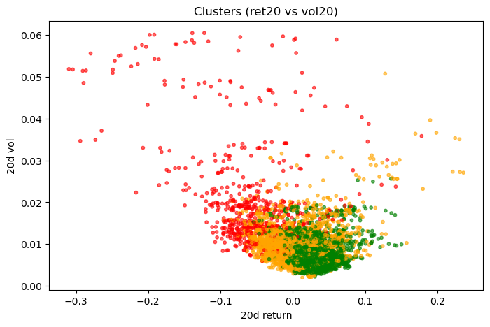

```python
# Color map for regimes
regime_colors = {
    "bear": "red",
    "neutral": "orange",
    "bull": "green"
}

# Scatter plot of momentum and volatility
plt.figure(figsize=(8,5))

plt.scatter(
    spy_feat["ret_20"],
    spy_feat["vol_20"],
    c=spy_feat["regime"].map(regime_colors),
    s=10,
    alpha=0.6
)

plt.xlabel("20d return")
plt.ylabel("20d vol")
plt.title("Clusters (ret20 vs vol20)")
plt.show()
```

#### Obervations:

- Bull regime (green) stays mostly in the low-vol, slightly positive return region. This fits with the old saying that markets "take stairs up and elevators down."
- Likewise bear regime (red)) you can easily see has more outlying plots in high volatility and low return space.
- Neutral (orange) occupies space between, transitionary state between other two.

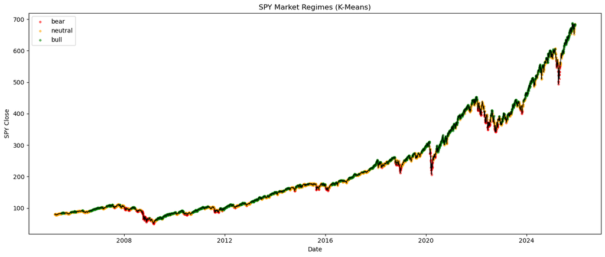

```python
# Plot Market Regimes
import matplotlib.pyplot as plt

plt.figure(figsize=(14,6))

# Base price line
plt.plot(spy_feat["Date"], spy_feat["Close"], color="black", linewidth=1)

# Regime-colored scatter overlay
for r in ["bear", "neutral", "bull"]:
    s = spy_feat[spy_feat["regime"] == r]
    plt.scatter(
        s["Date"],
        s["Close"],
        s=10,
        alpha=0.5,
        color=regime_colors[r],
        label=r
    )

plt.title("SPY Market Regimes (K-Means)")
plt.xlabel("Date")
plt.ylabel("SPY Close")
plt.legend()
plt.tight_layout()
plt.show()
```

#### Obervations:

- Clustering does a fairly good job at capturing large and quick bear events.
- The bull and neutral regimes are stable for long periods. The bear regimes less so.
- Quick visual suggests does a decent job capturing regimes. However, it might not work as a leading indicator.
- Gaussian Mixture Modeling (GMM) might be useful as it provides a probability that any given day belongs to a certain regime.
- Perhaps even more useful than GMM as a leading indicator could be Hidden Markov Modeling (HMM) as it predicts the probability of transitioning regimes. Will add these to future research.

### 5. Technical Screener for Alpha Generation

```python
# Begin build technical indicator table
import pandas as pd
import pandas_ta as ta

# Load price history (long format)
prices = pd.read_csv("weeklies_prices_long.csv")
prices["Date"] = pd.to_datetime(prices["Date"])

# Load Reddit daily sentiment
sent = pd.read_csv("ticker_daily_sentiment.csv")
sent["date"] = pd.to_datetime(sent["date"]).dt.date
sent = sent.rename(columns={"date": "Date"})
```

```python
# Define TA indicators and appropriate daily periods
# Indicators inspired by "Key technical indicators for stock market prediction" (Mostafavi and Hooman, 2025)

def add_indicators(df):
    df = df.sort_values("Date").copy()

    # Short-term (5)
    df["sma_5"] = ta.sma(df["Close"], 5)
    df["hma_5"] = ta.hma(df["Close"], 5)
    df["tema_5"] = ta.tema(df["Close"], 5)
    df["roc_5"] = ta.roc(df["Close"], 5)

    # Bi-week (10)
    df["sma_10"] = ta.sma(df["Close"], 10)
    df["ema_10"] = ta.ema(df["Close"], 10)
    df["kama_10"] = ta.kama(df["Close"], 10)

    # Two-week (Swing) (14)
    df["rsi_14"] = ta.rsi(df["Close"], 14)
    df["atr_14"] = ta.atr(df["High"], df["Low"], df["Close"], 14)

    # Monthly (20)
    df["ema_20"] = ta.ema(df["Close"], 20)
    bb = ta.bbands(df["Close"], length=20)
    df["bb_low"]  = bb["BBL_20_2.0_2.0"]
    df["bb_mid"]  = bb["BBM_20_2.0_2.0"]
    df["bb_high"] = bb["BBU_20_2.0_2.0"]

    # Long-term
    df["sma_50"] = ta.sma(df["Close"], 50)
    df["sma_200"] = ta.sma(df["Close"], 200)

    # Volume-based
    df["obv"] = ta.obv(df["Close"], df["Volume"])
    df["mfi_14"] = ta.mfi(df["High"], df["Low"], df["Close"], df["Volume"])
    df["pvt"] = ta.pvt(df["Close"], df["Volume"])

    # MACD (standard)
    macd = ta.macd(df["Close"])
    df["macd"] = macd["MACD_12_26_9"]
    df["macd_signal"] = macd["MACDs_12_26_9"]
    df["macd_hist"] = macd["MACDh_12_26_9"]

    return df
```

```python
# Apply indicators to tickers
prices_ta = (
    prices
    .groupby("Ticker")
    .apply(add_indicators)
    .reset_index(drop=True)
)
```

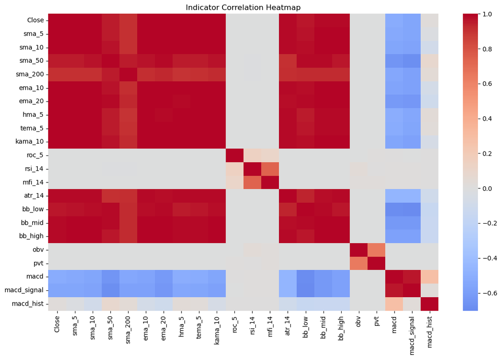

```python
# Quick correlation matrix to visualize columns
import seaborn as sns
import matplotlib.pyplot as plt

cols = [
    "Close", "sma_5", "sma_10", "sma_50", "sma_200",
    "ema_10", "ema_20",
    "hma_5", "tema_5", "kama_10",
    "roc_5",
    "rsi_14", "mfi_14",
    "atr_14",
    "bb_low", "bb_mid", "bb_high",
    "obv", "pvt",
    "macd", "macd_signal", "macd_hist"
]

# Build correlation matrix
corr = prices_ta[cols_avail].corr()

plt.figure(figsize=(12,8))
sns.heatmap(corr, cmap="coolwarm", center=0, annot=False)
plt.title("Indicator Correlation Heatmap")
plt.tight_layout()
plt.show()
```

#### Observations:

- Not much value, just wanted to make sure columns were populated with data.

```python
# Quick sortable/filterable table
from dash import Dash, dash_table, html
import pandas as pd

df = df_last.copy().round(2)

app = Dash(__name__)

app.layout = html.Div([
    dash_table.DataTable(
        df.to_dict("records"),
        [{"name": c, "id": c} for c in df.columns],
        sort_action="native",
        filter_action="native",
        page_size=20
    )
])

app.run(debug=True)
```

[interactive chart not shown]

#### Obervations:

- We should have all the data needed to run some strategy backtesting on now.
- The CSV with TA indicators has ballooned to 700MB, I might want to start familiarizing with Parquet files to reduce space and optimize backtest computing.
- Dash easily creates an interactive sorting/filterable table, but not really production quality. Hopefully incorporate some useful filters from strategy stage in future work.

```python
# Quick CSV backup before continuing
from datetime import date

# Save timestamped CSV
fname = f"technical_indicators_backup_{date.today()}.csv"
prices_ta.to_csv(fname, index=False)
print("Saved:", fname)

# Save latest CSV
fname = f"technical_indicators_backup.csv"
prices_ta.to_csv(fname, index=False)
print("Saved:", fname)
```

```
Saved: technical_indicators_backup_2025-12-07.csv
Saved: technical_indicators_backup.csv
```

### 6. Strategy Backtesting

```python
# Begin backtesting module

# Import CSV from Weeklies TA Daily
prices_ta = pd.read_csv("technical_indicators_backup.csv", parse_dates=["Date"])

# Convert to vectorbt format (Date x Ticker)
close_df  = df.pivot(index="Date", columns="Ticker", values="Close")
open_df   = df.pivot(index="Date", columns="Ticker", values="Open")
high_df   = df.pivot(index="Date", columns="Ticker", values="High")
low_df    = df.pivot(index="Date", columns="Ticker", values="Low")
volume_df = df.pivot(index="Date", columns="Ticker", values="Volume")
```

```python
# Build out vectorbt indicators
import vectorbt as vbt

def indicator_pack_vbt(close, high, low, volume):
    out = {}

    # Trend / Moving Averages
    out["sma_5"]   = vbt.MA.run(close, 5).ma
    out["sma_10"]  = vbt.MA.run(close, 10).ma
    out["sma_20"]  = vbt.MA.run(close, 20).ma
    out["sma_50"]  = vbt.MA.run(close, 50).ma
    out["sma_200"] = vbt.MA.run(close, 200).ma

    # RSI
    out["rsi_14"] = vbt.RSI.run(close, 14).rsi

    # MACD
    macd = vbt.MACD.run(close)
    out["macd"] = macd.macd
    out["macd_signal"] = macd.signal
    out["macd_hist"] = macd.hist

    # Volatility
    bb = vbt.BBANDS.run(close, window=20)
    out["bb_low"]  = bb.lower
    out["bb_mid"]  = bb.middle
    out["bb_high"] = bb.upper

    # Volume
    out["obv"] = vbt.OBV.run(close, volume).obv

    return out
```

```python
# Apply indicators to vectorbt pivot table
inds = indicator_pack_vbt(close=close_df, high=high_df, low=low_df, volume=volume_df)
```

```python
# Normalize
def normalize(df, name):
    df = pd.DataFrame(df)
    # flatten columns: name_indicator_ticker
    df.columns = [f"{name}_{col}" for col in df.columns]
    return df
```

```python
# Concenate/Combine into large table
ind_df = pd.concat(
    [normalize(df, name) for name, df in inds.items()],
    axis=1
)
```

```python
for name, df in inds.items():
    print(name, df.shape, type(df.columns))
```

```
sma_5 (1, 663) <class 'pandas.core.indexes.multi.MultiIndex'>
sma_10 (1, 663) <class 'pandas.core.indexes.multi.MultiIndex'>
sma_20 (1, 663) <class 'pandas.core.indexes.multi.MultiIndex'>
sma_50 (1, 663) <class 'pandas.core.indexes.multi.MultiIndex'>
sma_200 (1, 663) <class 'pandas.core.indexes.multi.MultiIndex'>
rsi_14 (1, 663) <class 'pandas.core.indexes.multi.MultiIndex'>
macd (1, 663) <class 'pandas.core.indexes.base.Index'>
macd_signal (1, 663) <class 'pandas.core.indexes.base.Index'>
macd_hist (1, 663) <class 'pandas.core.indexes.base.Index'>
bb_low (1, 663) <class 'pandas.core.indexes.multi.MultiIndex'>
bb_mid (1, 663) <class 'pandas.core.indexes.multi.MultiIndex'>
bb_high (1, 663) <class 'pandas.core.indexes.multi.MultiIndex'>
obv (1, 663) <class 'pandas.core.indexes.base.Index'>
```

#### Something is wrong here. I will download new clean data for backtest, and debug this later.

```python
# Clean data download and indicators for simple strategy backtest
import yfinance as yf
import pandas as pd
import vectorbt as vbt

tickers = ["SPY", "GLD", "TLT"]

raw = yf.download(tickers, start="2005-01-01", end="2025-12-31")

close  = raw["Close"]
high   = raw["High"].reindex_like(close)
low    = raw["Low"].reindex_like(close)
volume = raw["Volume"].reindex_like(close)
```

```python
# Build and flatten indicators
sma20 = vbt.MA.run(close, 20).ma
sma20.columns = close.columns

macd_obj = vbt.MACD.run(close)

macd        = macd_obj.macd
macd_signal = macd_obj.signal
macd_hist   = macd_obj.hist

macd.columns        = close.columns
macd_signal.columns = close.columns
macd_hist.columns   = close.columns

rsi14 = vbt.RSI.run(close, 14).rsi
rsi14.columns = close.columns
```

```python
# Force re-alignment
idx = close.index

close       = close.reindex(idx)
sma20       = sma20.reindex(idx)
macd        = macd.reindex(idx)
macd_signal = macd_signal.reindex(idx)
rsi14       = rsi14.reindex(idx)
```

```python
# Build entry/exit signals
macd = inds["macd"]
signal = inds["macd_signal"]
hist = macd - signal

entries = hist.vbt.crossed_above(0)
exits   = hist.vbt.crossed_below(0)

entries = entries.fillna(False)
exits   = exits.fillna(False)
```

```python
# Run backtest
pf = vbt.Portfolio.from_signals(
    close=price,
    entries=entries,
    exits=exits,
    init_cash=100_000,
    fees=0.0005,     # optional
    slippage=0.0002, # optional
)
```

```python
# Display results
metrics = pf.stats(
    settings=dict(
        profit_factor=dict(require=False),
        expectancy=dict(require=False),
        omega_ratio=dict(require=False),
        sharpe_ratio=dict(require=False),
        sortino_ratio=dict(require=False),
        calmar_ratio=dict(require=False),
    ),
    silence_warnings=True
)

metrics
```

```
Start                         2015-01-02 00:00:00
End                           2025-12-05 00:00:00
Period                                       2749
Start Value                              100000.0
End Value                           126904.280538
Total Return [%]                        26.904281
Benchmark Return [%]                   147.259418
Max Gross Exposure [%]                      100.0
Total Fees Paid                      10960.997838
Max Drawdown [%]                        32.694406
Max Drawdown Duration                 1045.333333
Total Trades                                 99.0
Total Closed Trades                          98.0
Total Open Trades                             1.0
Open Trade PnL                        1107.505174
Win Rate [%]                            46.113843
Best Trade [%]                          10.974338
Worst Trade [%]                         -8.777201
Avg Winning Trade [%]                    2.961829
Avg Losing Trade [%]                    -2.111239
Avg Winning Trade Duration              17.897407
Avg Losing Trade Duration               10.127544
Profit Factor: require                      False
Expectancy: require                         False
Name: agg_func_mean, dtype: object
```

```python
# Benchmark = SPY buy & hold
spy_close = close_df["SPY"]

try:
    spy_bench = vbt.Portfolio.from_holding(
        close=spy_close,
        init_cash=100_000
    ).value()
except:
    # older vectorbt compatibility
    spy_bench = vbt.Portfolio.from_holding(
        price=spy_close,
        init_cash=100_000
    ).value()

spy_bench.tail()
```

```
Date
2025-12-01    331144.450073
2025-12-02    331757.802461
2025-12-03    332906.605185
2025-12-04    333149.997103
2025-12-05    333782.810149
Name: SPY, dtype: float64
```

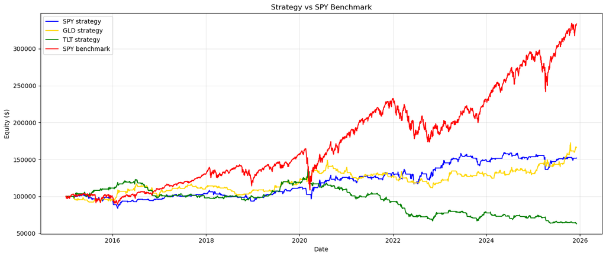

```python
import matplotlib.pyplot as plt

colors = {"SPY": "blue", "GLD": "gold", "TLT": "green"}

plt.figure(figsize=(14,6))

# Plot strategy curves
for t in equity.columns:
    plt.plot(equity.index, equity[t], label=f"{t} strategy", color=colors.get(t))

# Plot benchmark
plt.plot(spy_bench.index, spy_bench, label="SPY benchmark", color="red")

plt.title("Strategy vs SPY Benchmark")
plt.xlabel("Date")
plt.ylabel("Equity ($)")
plt.legend()
plt.grid(True, alpha=0.3)
plt.tight_layout()
plt.show()
```

#### Observations:

- So the simple MACD crossover strategy got absolutely crushed and greatly underperformed the SP500.
- However, I am happy with this outcome as I just wanted some backtesting to post for the class exercise, and to help me on the path of developing a backtesting platform.

### 7. Future Roadmap and Research

1. **Simplify, Steamline and Remove Non-Productive Components**
- Focus only on sources and indicators that consistently add value.
- Retire Reddit JSON scraping (too noisy, low predictive power without major ML work).
- Hopefully replace with simple data feed solution, or Reddit API if it comes back online.
- Move valid functions to top of IPYNB: download/update and clean market/options data, build/enrich with technical signals and other enrichment services.
2. **Improve Backtesting Infrastructure**
- I'm hoping to get a faster, simpler, more reliable research environment, as vectorbt caused many headaches.
- Evaluate other python backtesting engines, such as: backtesting.py, backtrader, QuantConnect Lean (local), etc.
3. **Build Robust Options Data Workflows**
- Figre out way to download, and more importantly effectively store numerous options chains (look into Parquet files)
- Backtesting agent will have to have options compatability.
4. **Create a Unified Backtesting Framework**
- Once backtesting agent(s) picked and data pipelines fixed hopefully have a modular and reusable, rapid backtesting framework.
- Standard snipet functions for loading/selecting tickers, adding technical indicators and/or other enriched data, generating signals, backtesting and ranking results.
- Integrated and defined risk management parameters.
5. **Generate Production-Ready Python Scripts**
- Once a strategy is validated, I'm hoping the framework can output: clean .py files
- .py files will push properly sized and risk controlled orders to include entry and exit target and exit stoploss to IBKR brokerage API.
- Positions will be monitored in native brokerage software.

**So bottom line hoping the workflow can go like this:**

1. Research strategies
2. Approve a strategy with defined parameters
3. Auto-export to a deployable trading script

### 8. References

Hutto, C., & Gilbert, E. (2014). VADER: A Parsimonious Rule-Based Model for Sentiment Analysis of Social Media Text. Proceedings of the International AAAI Conference on Web and Social Media, 8(1), 216-225. https://doi.org/10.1609/icwsm.v8i1.14550  
(Industry-standard sentiment tool widely used for Reddit, Twitter, and short-form text sentiment.)

Kashcha, A. (2023). Reddit Discovery (redsim). GitHub repository.  
https://github.com/anvaka/redsim  
(Useful to help identify and source similar subreddits.)

Mostafavi, S. M., & Hooman, A. R. (2025). Key technical indicators for stock market prediction. Machine Learning with Applications, 20, 100631. https://doi.org/10.1016/j.mlwa.2025.100631  
(Used to define most potentially useful technical indicators.)

Polakow, O. (n.d.). GitHub - polakowo/vectorbt. Github. Retrieved 17 November. 2025, from https://github.com/polakowo/vectorbt.  
(Python backtesting library agent used.)

Reddit Inc. (2025). Responsible Builder Policy & API Access Guidelines. Retrieved from: https://www.reddit.com/r/redditdev/comments/1oug31u/introducing_the_responsible_builder_policy_new/  
(Reddit private API policy update.)